# ds202_HW4

Chase Weida; Github: cweida

3/3/2020

### 1

Get a frequency breakdown of the number of chicks, their average weight and the standard deviation of the weights in each of the diets at the start of the study. Store the resulting data frame in a variable named weight0 and print.

```r
dat1 <- ChickWeight %>%
  filter(Time == 0) %>%
  group_by(Diet) %>%
  summarize(average_weight = mean(weight, na.rm = TRUE),
            sd_weight = sd(weight, na.rm = TRUE))

dat2 <- ChickWeight %>% filter(Time == 0) %>% group_by(Chick)
weight0 <- data.frame(dat1)
weight0[1:4,"Frequency"] <- c(sum(dat2$Diet == 1),sum(dat2$Diet == 2),sum(dat2$Diet == 3),sum(dat2$Diet == 4))
weight0
```

```
##   Diet average_weight sd_weight Frequency
## 1    1           41.4 0.9947229        20
## 2    2           40.7 1.4944341        10
## 3    3           40.8 1.0327956        10
## 4    4           41.0 1.0540926        10
```

### 2

Each chick should have twelve weight measurements. Use the dplyr package to identify how many measurements are there for each chick. Extract a subset of the data for all chicks with complete information, name the data set complete, and print the first 3 rows. (Hint: you might want to use mutate to introduce a helper variable consisting of the number of observations)

```r
ChickWeight %>% group_by(Chick) %>% summarize(n = n())
```

```
## # A tibble: 50 x 2
##    Chick     n
##    <ord> <int>
##  1 18        2
##  2 16        7
##  3 15        8
##  4 13       12
##  5 9        12
##  6 20       12
##  7 10       12
##  8 8        11
##  9 17       12
## 10 19       12
## # … with 40 more rows
```

```r
complete <- ChickWeight[ChickWeight$Chick %notin% c(18,16,15),]
head(complete,3)
```

```
## Grouped Data: weight ~ Time | Chick
##   weight Time Chick Diet
## 1     42    0     1    1
## 2     51    2     1    1
## 3     59    4     1    1
```

### 3

In the complete data set introduce a new variable that measures the current weight difference compared to day 0. Name this variable weightgain and print the first 3 rows of the new data frame.

```r
complete <- complete %>% group_by(Chick) %>% mutate(weightgain = weight - weight[1])
head(complete,3)
```

```
## # A tibble: 3 x 5
## # Groups:   Chick [1]
##   weight  Time Chick Diet  weightgain
##    <dbl> <dbl> <ord> <fct>      <dbl>
## 1     42     0 1     1              0
## 2     51     2 1     1              9
## 3     59     4 1     1             17
```

### 4

Use {ggplot2} to create side-by-side boxplots of weightgain by Diet for day 21. Change the order of the categories in the Diet variable such that the boxplots are ordered by median weightgain, and the lower limit of the y axis should be 0. Describe the relationship in 2-3 sentences.

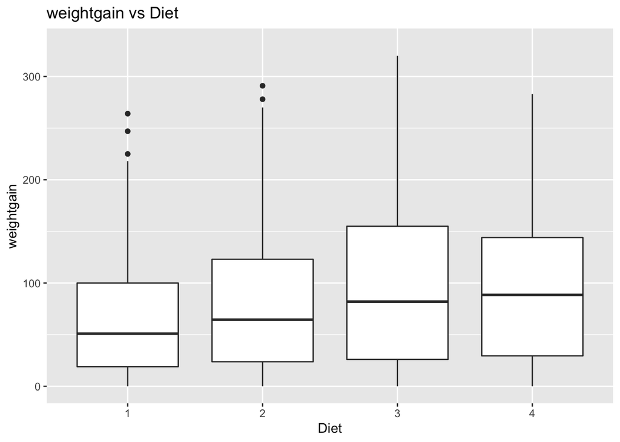

```r
ggplot(data = complete, mapping = aes(y = weightgain, x = reorder(Diet, weightgain, FUN = median))) + xlab("Diet") +ggtitle("weightgain vs Diet")+ geom_boxplot() + ylim(0,330)
```

### 5

Answer each of the following questions using numerical and graphical summary. Also explain what you found: (a) Which chick gained the most weight and which gained the least weight? (b) What diets were they on?

```r
finalWeek <- complete %>% filter(Time == 21)
Max <- max(finalWeek$weightgain)
Min <- min(finalWeek$weightgain)




maxDiet <- complete %>% filter(Time == 21, weightgain == Max)
minDiet <- complete %>% filter(Time == 21, weightgain == Min)
Min
```

```
## [1] 32
```

```r
Max
```

```
## [1] 332
```

```r
maxDiet$Chick
```

```
## [1] 35
## 47 Levels: 13 < 9 < 20 < 10 < 8 < 17 < 19 < 4 < 6 < 11 < 3 < 1 < 12 < ... < 48
```

```r
minDiet$Chick
```

```
## [1] 24
## 47 Levels: 13 < 9 < 20 < 10 < 8 < 17 < 19 < 4 < 6 < 11 < 3 < 1 < 12 < ... < 48
```

```r
maxDiet$Diet
```

```
## [1] 3
## Levels: 1 2 3 4
```

```r
minDiet$Diet
```

```
## [1] 2
## Levels: 1 2 3 4
```

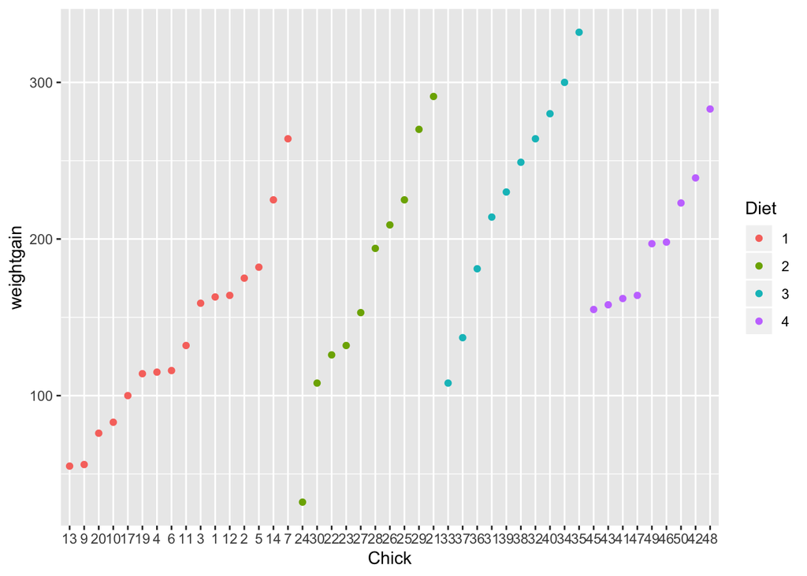

```r
ggplot(finalWeek, aes(x = Chick, y = weightgain, color = Diet)) + geom_point()
```

The above code extracted the highest and lowest weight gain, their identification number, and which diet they were on. The chick with the highest weight gain was number 35 who gained 332 units on diet 3. The lowest weight gain was from chick 24 with 32 units gained on diet 2.

### 6

For the chicks with the least and the most weight at time 0, plot their growth trajectories over time.

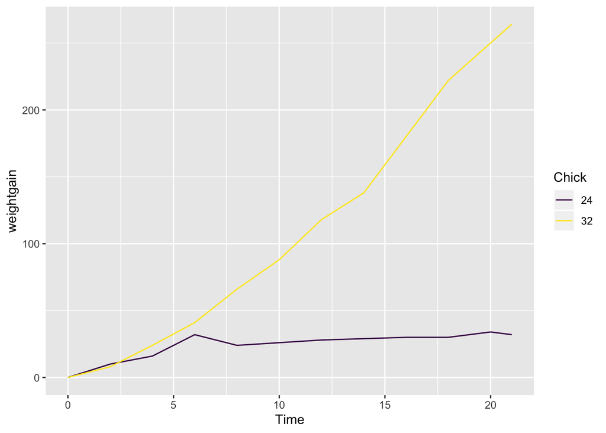

```r
MinMax <- complete %>% filter(Chick %in% c(24,32))
ggplot(MinMax, aes(x = Time, y = weightgain, color = Chick)) + geom_line()
```

As seen above, the two chicks grew together until about the 6 unit mark. At which point chick 24’s weight gain dropped slightly and leveled out for the remaineder of the experiment. Chick 32 on the other hand experienced linear growth over the course of the experiment.

### 7

Add to the previous plot the average growth trajectory for all chicks (calculated as the mean weight for each chick at each time). How do the trajectories compare?

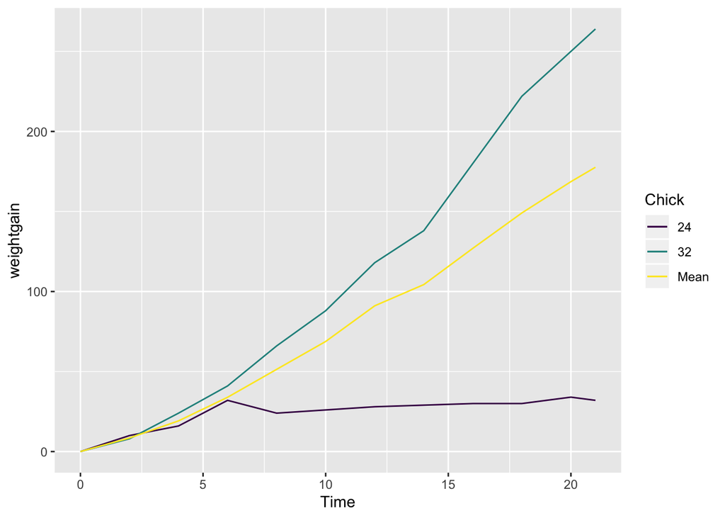

```r
MeanGain <- complete %>% group_by(Time) %>% summarize(MeanAtTime = mean(weightgain))

MeanGain["Time"] <- complete$Time[1:12]
MeanGain["Chick"] <- c("Mean", "Mean", "Mean", "Mean", "Mean", "Mean", "Mean", "Mean", "Mean", "Mean", "Mean", "Mean")
ggplot(MinMax, aes(x = Time, y = weightgain, color = Chick)) + geom_line() + geom_line(MeanGain, mapping = aes(x = Time, y = MeanAtTime))
```

### 8

What else do you find interesting in the dataset? Show your exploratory analysis.

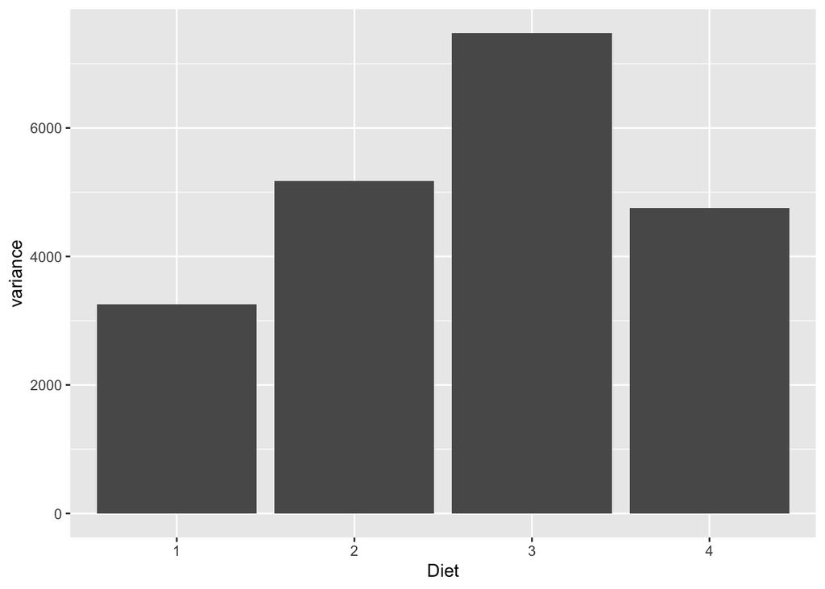

```r
MinMaxVarDiet <- complete %>% group_by(Diet) %>% summarize(variance = var(weightgain), min = min(weightgain), max = max(weightgain))

ggplot(MinMaxVarDiet) + geom_bar(mapping = aes(x = Diet, y = variance), stat = "identity")
```

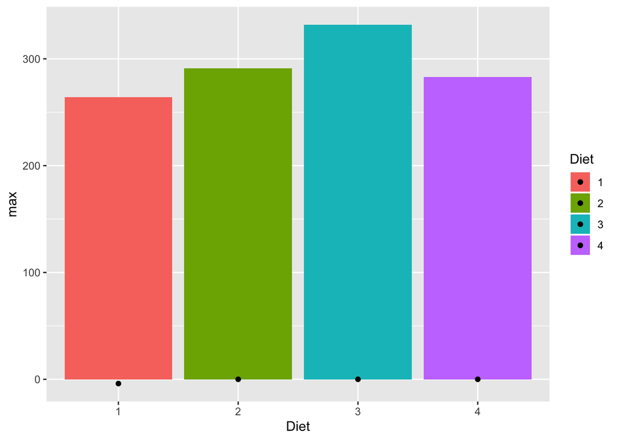

```r
ggplot(MinMaxVarDiet) + geom_bar(mapping = aes(x = Diet, y = max, fill = Diet), stat = "identity") + geom_point(mapping = aes(x = Diet, y = min, fill = Diet), stat = "identity")
```